# Climate Change Analysis

# Climate change and temperature anomalies

If we wanted to study climate change, we can find data on the *Combined Land-Surface Air and Sea-Surface Water Temperature Anomalies* in the Northern Hemisphere at [NASA’s Goddard Institute for Space Studies](https://data.giss.nasa.gov/gistemp). The [tabular data of temperature anomalies can be found here](https://data.giss.nasa.gov/gistemp/tabledata_v4/NH.Ts+dSST.txt)

To define temperature anomalies you need to have a reference, or base, period which NASA clearly states that it is the period between 1951-1980.

Run the code below to load the file:

```r
weather <-
  read_csv("https://data.giss.nasa.gov/gistemp/tabledata_v4/NH.Ts+dSST.csv",
           skip = 1,
           na = "***")
```

Notice that, when using this function, we added two options: `skip` and `na`.

1. The `skip=1` option is there as the real data table only starts in Row 2, so we need to skip one row.
2. `na = "***"` option informs R how missing observations in the spreadsheet are coded. When looking at the spreadsheet, you can see that missing data is coded as “***”. It is best to specify this here, as otherwise some of the data is not recognized as numeric data.

Once the data is loaded, notice that there is a object titled `weather` in the `Environment` panel. If you cannot see the panel (usually on the top-right), go to `Tools` > `Global Options` > `Pane Layout` and tick the checkbox next to `Environment`. Click on the `weather` object, and the dataframe will pop up on a seperate tab. Inspect the dataframe.

For each month and year, the dataframe shows the deviation of temperature from the normal (expected). Further the dataframe is in wide format.

You have two objectives in this section:

1. Select the year and the twelve month variables from the `weather` dataset. We do not need the others (J-D, D-N, DJF, etc.) for this assignment. Hint: use `select()` function.
2. Convert the dataframe from wide to ‘long’ format. Hint: use `gather()` or `pivot_longer()` function. Name the new dataframe as `tidyweather`, name the variable containing the name of the month as `month`, and the temperature deviation values as `delta`.

```r
weather %>%
  select(1:13)
```

```
## # A tibble: 143 × 13
##     Year   Jan   Feb   Mar   Apr   May   Jun   Jul   Aug   Sep   Oct   Nov   Dec
##    <dbl> <dbl> <dbl> <dbl> <dbl> <dbl> <dbl> <dbl> <dbl> <dbl> <dbl> <dbl> <dbl>
##  1  1880 -0.39 -0.53 -0.23 -0.3  -0.05 -0.18 -0.21 -0.25 -0.24 -0.3  -0.43 -0.42
##  2  1881 -0.3  -0.24 -0.05 -0.02  0.05 -0.33  0.1  -0.04 -0.28 -0.44 -0.36 -0.23
##  3  1882  0.26  0.21  0.02 -0.3  -0.23 -0.28 -0.28 -0.14 -0.24 -0.51 -0.33 -0.68
##  4  1883 -0.58 -0.66 -0.15 -0.3  -0.25 -0.11 -0.05 -0.22 -0.34 -0.16 -0.44 -0.15
##  5  1884 -0.16 -0.11 -0.64 -0.59 -0.36 -0.41 -0.41 -0.51 -0.45 -0.44 -0.57 -0.47
##  6  1885 -1.01 -0.45 -0.23 -0.49 -0.58 -0.45 -0.34 -0.41 -0.4  -0.37 -0.38 -0.11
##  7  1886 -0.75 -0.84 -0.71 -0.37 -0.34 -0.37 -0.14 -0.43 -0.33 -0.31 -0.4  -0.22
##  8  1887 -1.08 -0.71 -0.44 -0.38 -0.25 -0.2  -0.24 -0.54 -0.21 -0.49 -0.27 -0.43
##  9  1888 -0.49 -0.61 -0.64 -0.22 -0.15 -0.03  0    -0.21 -0.2  -0.03 -0.01 -0.24
## 10  1889 -0.28  0.29 -0.02  0.16 -0.04 -0.07 -0.08 -0.2  -0.3  -0.41 -0.62 -0.55
## # … with 133 more rows
## # ℹ Use `print(n = ...)` to see more rows
```

```r
tidyweather <- weather %>%
  pivot_longer(
    cols = 2:13,
    names_to="Month",
    values_to="delta"
    ) %>%
  select(Year, Month, delta)

tidyweather
```

```
## # A tibble: 1,716 × 3
##     Year Month delta
##    <dbl> <chr> <dbl>
##  1  1880 Jan   -0.39
##  2  1880 Feb   -0.53
##  3  1880 Mar   -0.23
##  4  1880 Apr   -0.3
##  5  1880 May   -0.05
##  6  1880 Jun   -0.18
##  7  1880 Jul   -0.21
##  8  1880 Aug   -0.25
##  9  1880 Sep   -0.24
## 10  1880 Oct   -0.3
## # … with 1,706 more rows
## # ℹ Use `print(n = ...)` to see more rows
```

Inspect your dataframe. It should have three variables now, one each for

1. year,
2. month, and
3. delta, or temperature deviation.

## Plotting Information

Let us plot the data using a time-series scatter plot, and add a trendline. To do that, we first need to create a new variable called `date` in order to ensure that the `delta` values are plot chronologically.

> In the following chunk of code, I used the `eval=FALSE` argument, which does not run a chunk of code; I did so that you can knit the document before tidying the data and creating a new dataframe `tidyweather`. When you actually want to run this code and knit your document, you must delete `eval=FALSE`, **not just here but in all chunks were `eval=FALSE` appears.**

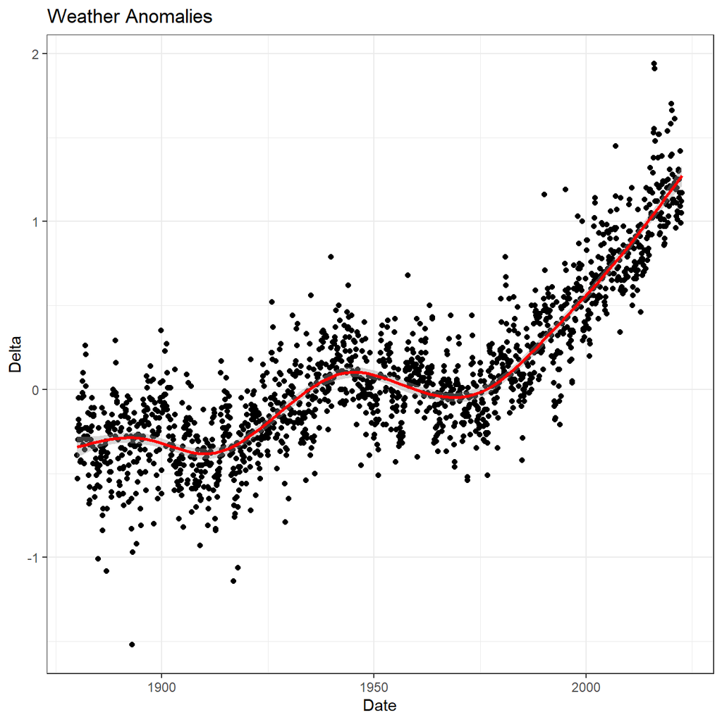

```r
tidyweather <- tidyweather %>%
  mutate(date = ymd(paste(as.character(Year), Month, "1")),
         month = month(date, label=TRUE),
         year = year(date))

ggplot(tidyweather, aes(x = date, y = delta)) +
  geom_point() +
  geom_smooth(color="red") +
  theme_bw() +
  labs(
    title = "Weather Anomalies",
    x = "Date",
    y = "Delta"
  )
```

Is the effect of increasing temperature more pronounced in some months? Use `facet_wrap()` to produce a seperate scatter plot for each month, again with a smoothing line. Your chart should human-readable labels; that is, each month should be labeled “Jan”, “Feb”, “Mar” (full or abbreviated month names are fine), not `1`, `2`, `3`.

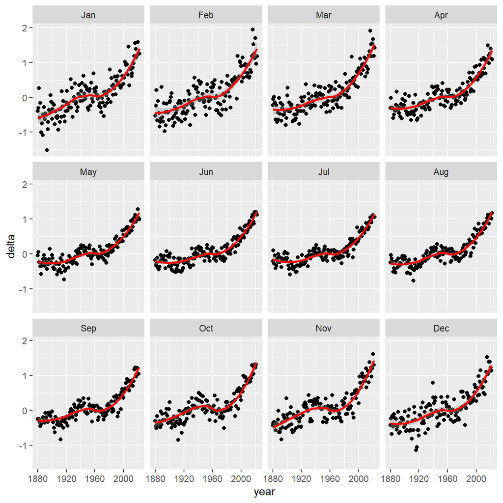

```r
#Your code goes here...
ggplot(tidyweather, aes(x = year, y = delta)) +
  geom_point() +
  facet_wrap(~month) +
  geom_smooth(color="red")
```

```r
  theme_bw() +
  labs (
    title = "Weather Anomalies",
    x = "Date",
    y = "Delta"
  )
```

[output not shown]

[output cut: 367 more lines]

[output not shown]

It is sometimes useful to group data into different time periods to study historical data. For example, we often refer to decades such as 1970s, 1980s, 1990s etc. to refer to a period of time. NASA calcuialtes a temperature anomaly, as difference form the base periof of 1951-1980. The code below creates a new data frame called `comparison` that groups data in five time periods: 1881-1920, 1921-1950, 1951-1980, 1981-2010 and 2011-present.

```r
comparison <- tidyweather %>%
  filter(Year>= 1881) %>%     #remove years prior to 1881
  #create new variable 'interval', and assign values based on criteria below:
  mutate(interval = case_when(
    Year %in% c(1881:1920) ~ "1881-1920",
    Year %in% c(1921:1950) ~ "1921-1950",
    Year %in% c(1951:1980) ~ "1951-1980",
    Year %in% c(1981:2010) ~ "1981-2010",
    TRUE ~ "2011-present"
  ))
```

Inspect the `comparison` dataframe by clicking on it in the `Environment` pane.

Now that we have the `interval` variable, we can create a density plot to study the distribution of monthly deviations (`delta`), grouped by the different time periods we are interested in. Set `fill` to `interval` to group and colour the data by different time periods.

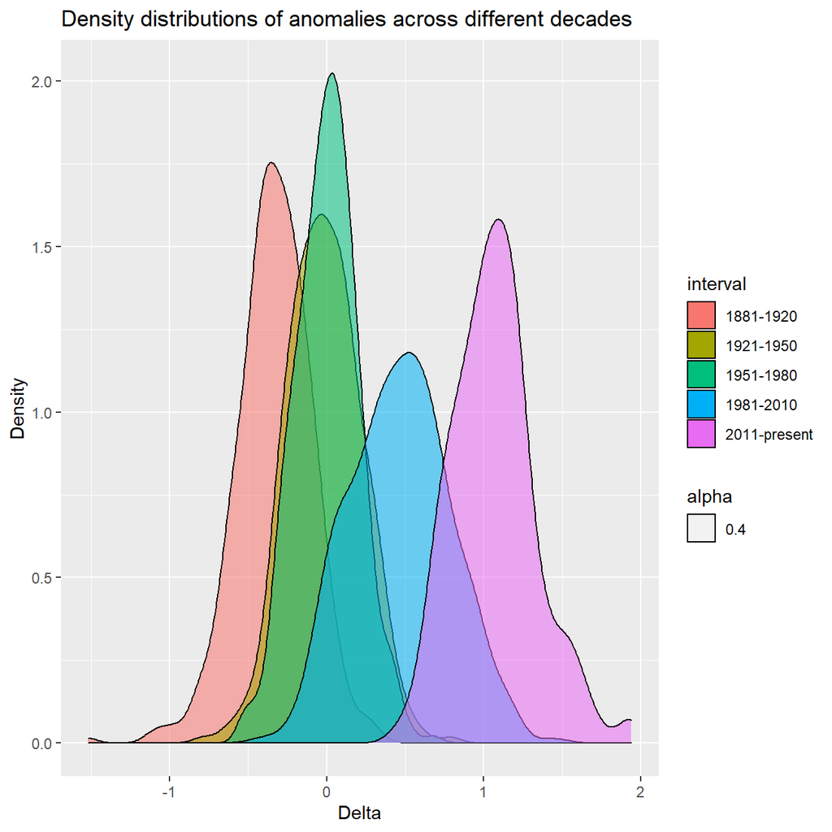

```r
ggplot(comparison, aes(x = delta, fill = interval, alpha = 0.4)) + # used 'alpha' for transparency since density plots overlap
  geom_density() +
  labs(title = "Density distributions of anomalies across different decades",
       x = "Delta",
       y = "Density")
```

```r
# added the below code to wrap by facet for better interpretation
  # ggplot(comparison, aes(x = delta, fill = interval)) +
  #   geom_density() +
  #   facet_wrap(~interval) +
    # labs(title = "Density distributions of anomalies across different decades",
    #      x = "Delta",
    #      y = "Density")
```

So far, we have been working with monthly anomalies. However, we might be interested in average annual anomalies. We can do this by using `group_by()` and `summarise()`, followed by a scatter plot to display the result.

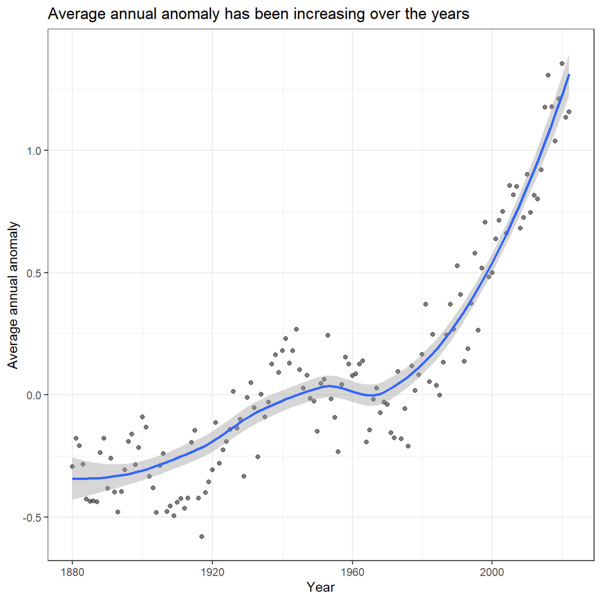

```r
#creating yearly averages
average_annual_anomaly <- tidyweather %>%
  group_by(Year) %>%   #grouping data by Year

  # creating summaries for mean delta
  # use `na.rm=TRUE` to eliminate NA (not available) values
  summarise(avg_annual_anomaly = mean(delta, na.rm = TRUE))

#plotting the data:

ggplot(average_annual_anomaly, aes(x = Year, y = avg_annual_anomaly)) +
  geom_point(alpha = 0.5) +
  #Fit the best fit line, using LOESS method
  geom_smooth(method = "loess") +
  #change theme to theme_bw() to have white background + black frame around plot
  theme_bw() +
  labs(title = "Average annual anomaly has been increasing over the years",
       x = "Year",
       y = "Average annual anomaly")
```

## Confidence Interval for `delta`

[NASA points out on their website](https://earthobservatory.nasa.gov/world-of-change/decadaltemp.php) that

> A one-degree global change is significant because it takes a vast amount of heat to warm all the oceans, atmosphere, and land by that much. In the past, a one- to two-degree drop was all it took to plunge the Earth into the Little Ice Age.

Your task is to construct a confidence interval for the average annual delta since 2011, both using a formula and using a bootstrap simulation with the `infer` package. Recall that the dataframe `comparison` has already grouped temperature anomalies according to time intervals; we are only interested in what is happening between 2011-present.

```r
# method 1: using forumla

formula_ci <- comparison %>%

  # choose the interval 2011-present
  # what dplyr verb will you use?
  filter(interval == "2011-present") %>%
 # group_by(Year) %>%
#  summarise(avg_delta_year = mean(delta, na.rm = TRUE)) %>%
  summarise(mean_delta = mean(delta, na.rm = TRUE),
            sd_delta = sd(delta, na.rm = TRUE),
            count = n(),
            se_delta = sd_delta/sqrt(count),
            t_critical_delta = qt(0.975, count - 1),
            moe_delta = t_critical_delta * se_delta,
            lower_ci_delta = mean_delta - moe_delta,
            upper_ci_delta = mean_delta + moe_delta)

  # calculate summary statistics for temperature deviation (delta)
  # calculate mean, SD, count, SE, lower/upper 95% CI
  # what dplyr verb will you use?


# replacing with more readable column names
colnames(formula_ci) <- c("Mean", "Standard Deviation", "Count" , "Standard Error", "t-critical", "Margin of Error", "Lower CI", "Higher CI")

#print out formula_CI
formula_ci
```

```
## # A tibble: 1 × 8
##    Mean `Standard Deviation` Count Standard Er…¹ t-cri…² Margi…³ Lower…⁴ Highe…⁵
##   <dbl>                <dbl> <int>         <dbl>   <dbl>   <dbl>   <dbl>   <dbl>
## 1  1.07                0.265   144        0.0221    1.98  0.0437    1.02    1.11
## # … with abbreviated variable names ¹`Standard Error`, ²`t-critical`,
## #   ³`Margin of Error`, ⁴`Lower CI`, ⁵`Higher CI`
```

```r
# method 2: using simulation
library(infer)

set.seed(3245)

bootstrap_ci <- comparison %>%
  filter(interval == "2011-present")


# performing a bootstrap simulation
bootstrap_ci %>%
  specify(response = delta) %>%
  generate(reps = 1000, type = "bootstrap") %>%
  calculate(stat = "mean") %>%
  get_confidence_interval(level = 0.95, type = "percentile")
```

```
## # A tibble: 1 × 2
##   lower_ci upper_ci
##      <dbl>    <dbl>
## 1     1.03     1.11
```

```r
colnames(bootstrap_ci) <- c("Lower Bound CI", "Upper Bound CI")
```

> What is the data showing us? Please type your answer after (and outside!) this blockquote. You have to explain what you have done, and the interpretation of the result. One paragraph max, please!